# The risks of misguided data analysis

Data management for the public sector

## DAGs and modeling

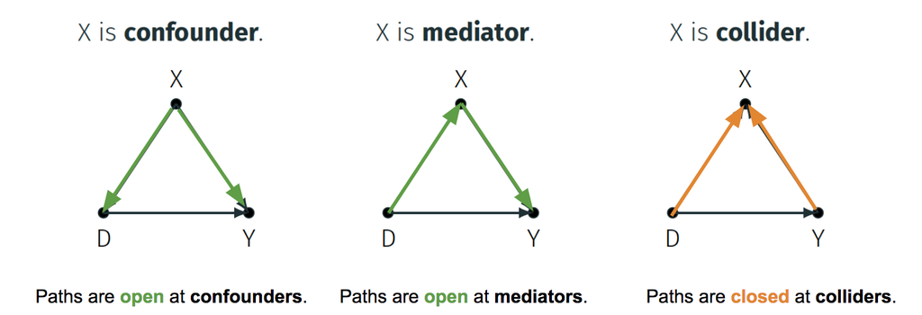

As we can remember from our slides, we were introduced to a set of **key** rules in understanding how to employ DAGs to guide our modeling strategy.

> - A path is open or unblocked at non-colliders (confounders or mediators)
> - A path is (naturally) blocked at colliders
> - An open path induces a statistical association between two variables
> - Absence of an open path implies statistical independence
> - Two variables are d-connected if there is an open path between them
> - Two variables are d-separated if the path between them is blocked

In this portion of the tutorial, we will demonstrate how different biases come to work when we model our relationships of interest.

## What happens when we control for a collider?

#### The case for beauty, talent, and celebrity (What happens when we control for a collider?)

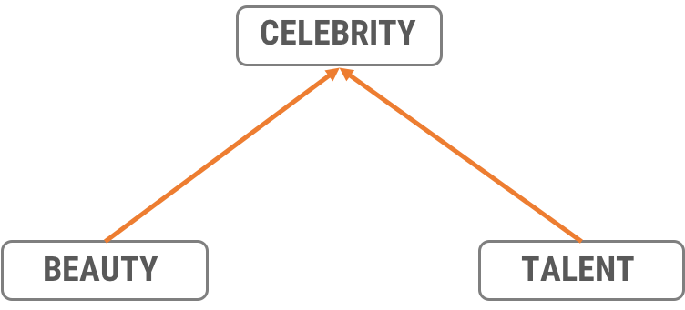

As it is showcased from our DAG, we assume that earning celebrity status is a function of an individual’s beauty and talent.

```r
# beauty - 1000 observations with mean 5 units of beauty and sd 1.5 (arbitrary scale)
beauty <- rnorm(1000, 5, 1.5)

# talent - 1000 observations with mean 3 units of talent and sd 1 (arbitrary scale)
talent <- rnorm(1000, 3, 1)

# celebrity - binary
celebrity_status <-  ifelse(beauty + talent > 8, "Celebrity" , "Not Celebrity") # celebrity if the sum of units  are greater than 8

celebrity_df <- dplyr::tibble(beauty, talent, celebrity_status) # we make a df with our values

head(celebrity_df, 10)
```

```
# A tibble: 10 × 3
   beauty talent celebrity_status
    <dbl>  <dbl> <chr>
 1   5.21  1.61  Not Celebrity
 2   2.79  5.48  Celebrity
 3   5.65  2.20  Not Celebrity
 4   6.87  4.17  Celebrity
 5   6.00  3.73  Celebrity
 6   7.44  2.33  Celebrity
 7   5.39  0.465 Not Celebrity
 8   5.50  4.14  Celebrity
 9   4.57  3.19  Not Celebrity
10   4.21  2.29  Not Celebrity
```

In this case, as our simulation suggests, we have a **collider structure**. We can see that celebrity can be a function of beauty or talent. Also, we can infer from the way we defined the variables that **beauty and talent are d-separated (ie. the path between them is closed because celebrity is a collider)**.

Say you are interested in researching the relationship between **beauty** and **talent** for your policy evaluation, while doing your literature review you encounter a series of papers that find a negative relationship between the two and state that more beautiful people tend to be less talented. The model that these teams of researchers used was the following:

$$Y_{Talent} = \beta_0 + \beta_1Beauty +
\beta_2Celebrity$$

Your evaluation hunch makes you believe that celebrity is a collider and that by controlling for it in their models, the researchers are inducing **collider bias**, or **endogenous bias**. You decide to move forward with your thesis by laying out criticism of previous work in the field, given that you consider the formalization of their models is erroneous. You utilize the same data previous papers used, but based on your logic, you do not control for celebrity status. This is what you find:

#### True model

```r
true_model_celebrity <- lm(talent ~ beauty, data = celebrity_df)

modelsummary::modelsummary(true_model_celebrity,
                           stars = c('*' = .1, '**' = .05, '***' = .01),
                           statistic = 'conf.int',
                           gof_omit = "AIC|BIC|Log.Lik.",
                           fmt = 2)
```

|  | (1) |
| --- | --- |
| (Intercept) | 3.15*** |
|  | [2.93, 3.36] |
| beauty | −0.03 |
|  | [−0.07, 0.01] |
| Num.Obs. | 1000 |
| R2 | 0.002 |
| R2 Adj. | 0.001 |
| F | 1.598 |
| RMSE | 0.99 |

* p < 0.1, ** p < 0.05, *** p < 0.01

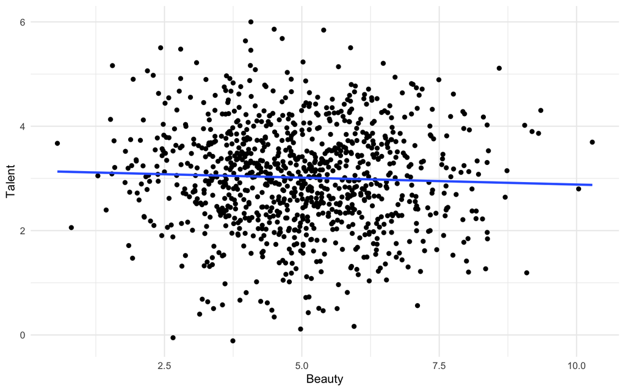

```r
ggplot(celebrity_df, aes(x=beauty,
                         y=talent)) +
  geom_point() +
  geom_smooth(method = "lm", se = F) +
  theme_minimal() +
  theme(legend.position = "bottom") +
  labs(x = "Beauty",
       y = "Talent")
```

#### Biased model from previous literature

Let’s see:

```r
biased_model_celibrity <- lm(talent ~ beauty + celebrity_status, data = celebrity_df)
modelsummary::modelsummary(biased_model_celibrity,
                           stars = c('*' = .1, '**' = .05, '***' = .01),
                           statistic = 'conf.int',
                           gof_omit = "AIC|BIC|Log.Lik.",
                           fmt = 2)
```

|  | (1) |
| --- | --- |
| (Intercept) | 5.64*** |
|  | [5.36, 5.93] |
| beauty | −0.37*** |
|  | [−0.41, −0.32] |
| celebrity_statusNot Celebrity | −1.53*** |
|  | [−1.67, −1.40] |
| Num.Obs. | 1000 |
| R2 | 0.327 |
| R2 Adj. | 0.326 |
| F | 242.538 |
| RMSE | 0.81 |

* p < 0.1, ** p < 0.05, *** p < 0.01

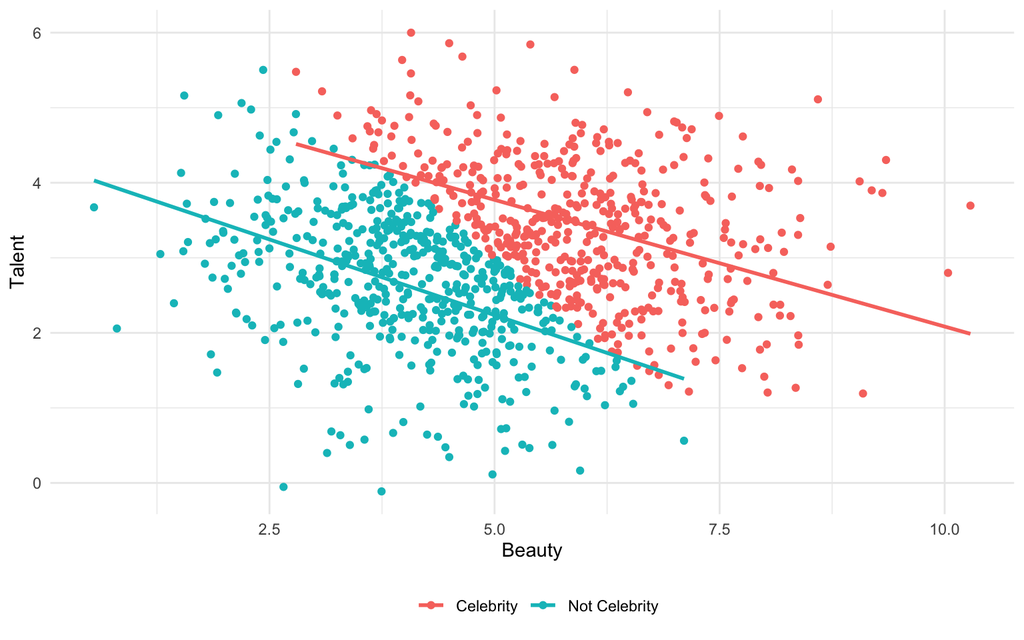

```r
ggplot(celebrity_df, aes(x=beauty, y=talent, color = celebrity_status)) +
  geom_point() +
  geom_smooth(method = "lm", se = F) +
  theme_minimal() +
  theme(legend.position = "bottom") +
  labs(x = "Beauty",
       y = "Talent",
       color = "")
```

> As we can see, by controlling for a collider, the previous literature was inducing a non-existent association between beauty and talent, also known as **collider** or **endogenous bias**.

## What happens when we fail to control for a confounder?

#### Shoe size and salary (What happens when we fail to control for a confounder?)

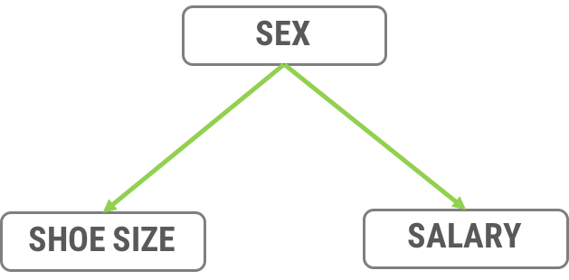

```r
# sex - replicate male and female 500 times each
sex <- rep(c("Male", "Female"), each = 500)

# shoe size - random number with mean 38 and sd 4, plus 4 if the observation is male
shoesize <- rnorm(1000, 38, 2) +  (4 * as.numeric(sex == "Male"))

# salary - a random number with mean 25 and sd 2, plus 5 if the observation is male
salary <- rnorm(1000, 25, 2) + (5 * as.numeric(sex == "Male"))

salary_df <- dplyr::tibble(sex, shoesize, salary)

head(salary_df, 10)
```

```
# A tibble: 10 × 3
   sex   shoesize salary
   <chr>    <dbl>  <dbl>
 1 Male      43.3   30.4
 2 Male      42.5   30.7
 3 Male      41.8   27.1
 4 Male      41.1   31.9
 5 Male      43.7   30.0
 6 Male      39.3   29.2
 7 Male      41.3   31.4
 8 Male      41.7   29.5
 9 Male      42.9   32.2
10 Male      41.1   29.3
```

Say now one of your peers tells you about this new study that suggests that **shoe size** affects an individuals’ **salary**. You are a bit skeptical and read it. The model that these researchers apply is the following:

$$Y_{Salary} = \beta_0 +
\beta_1ShoeSize$$

Your scientific hunch makes you believe that this relationship could be confounded by the **sex** of the respondent. You think that by failing to control for sex in their models, the researchers are inducing **omitted variable bias**. You decide to open their replication files and control for sex. This is what you find:

$$Y_{Salary} = \beta_0 + \beta_1ShoeSize +
\beta_2Sex$$

#### True model

```r
true_model_salary <- lm(salary ~ shoesize + sex, data = salary_df)
modelsummary::modelsummary(true_model_salary,
                           stars = c('*' = .1, '**' = .05, '***' = .01),
                           statistic = 'conf.int',
                           gof_omit = "AIC|BIC|Log.Lik.",
                           fmt = 2)
```

|  | (1) |
| --- | --- |
| (Intercept) | 25.67*** |
|  | [23.39, 27.95] |
| shoesize | −0.02 |
|  | [−0.08, 0.04] |
| sexMale | 5.07*** |
|  | [4.72, 5.41] |
| Num.Obs. | 1000 |
| R2 | 0.623 |
| R2 Adj. | 0.622 |
| F | 823.699 |
| RMSE | 1.94 |

* p < 0.1, ** p < 0.05, *** p < 0.01

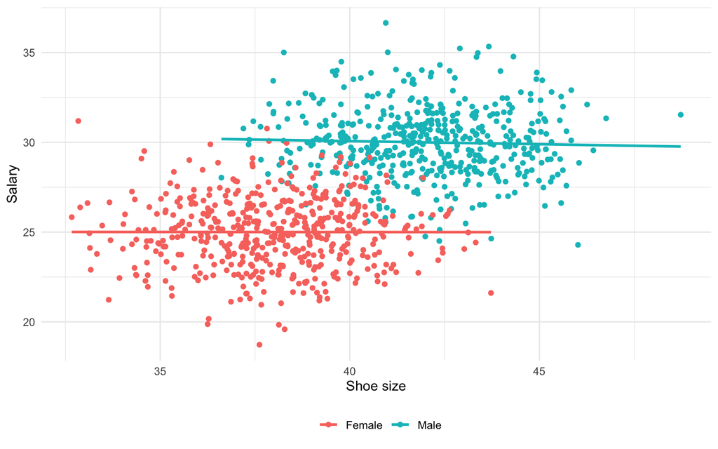

```r
ggplot(salary_df, aes(x=shoesize, y=salary, color = sex)) +
  geom_point() +
  geom_smooth(method = "lm", se = F) +
  theme_minimal() +
  theme(legend.position = "bottom") +
  labs(x = "Shoe size",
       y = "Salary",
       color = "")
```

#### Biased model from previous literature

```r
biased_model_salary <- lm(salary ~ shoesize, data = salary_df)
modelsummary::modelsummary(biased_model_salary,
                           stars = c('*' = .1, '**' = .05, '***' = .01),
                           statistic = 'conf.int',
                           gof_omit = "AIC|BIC|Log.Lik.",
                           fmt = 2)
```

|  | (1) |
| --- | --- |
| (Intercept) | 3.11*** |
|  | [0.81, 5.41] |
| shoesize | 0.61*** |
|  | [0.55, 0.67] |
| Num.Obs. | 1000 |
| R2 | 0.303 |
| R2 Adj. | 0.303 |
| F | 434.396 |
| RMSE | 2.64 |

* p < 0.1, ** p < 0.05, *** p < 0.01

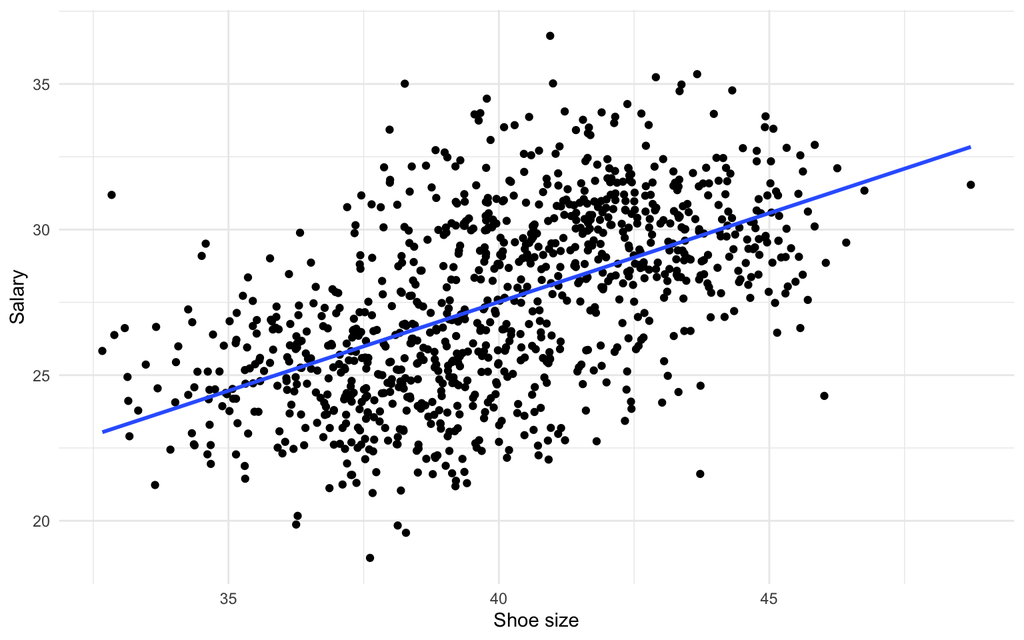

```r
ggplot(salary_df, aes(x=shoesize, y=salary)) +
  geom_point() +
  geom_smooth(method = "lm", se = F) +
  theme_minimal() +
  labs(x = "Shoe size",
       y = "Salary")
```

> As we can see, by failing to control for a confounder, the previous literature was creating a non-existent association between shoe size and salary, incurring in **omitted variable bias**.